# W3cubDocs

/Kotlin

# Debug coroutines using IntelliJ IDEA

| **Last Updated** | 17 September 2020 |
| --- | --- |

This tutorial demonstrates how to create Kotlin coroutines and debug them using IntelliJ IDEA.

The tutorial assumes you have prior knowledge of the coroutines concept.

> Debugging works for `kotlinx-coroutines-core` version 1.3.8 or later.

## Create coroutines

1. Open a Kotlin project in IntelliJ IDEA. If you don't have a project, create one.
2. Open the `main.kt` file in `src/main/kotlin`.

   The `src` directory contains Kotlin source files and resources. The `main.kt` file contains sample code that will print `Hello World!`.
3. Change code in the `main()` function:
   - Use the [`runBlocking()`](https://kotlin.github.io/kotlinx.coroutines/kotlinx-coroutines-core/kotlinx.coroutines/run-blocking.html) block to wrap a coroutine.
   - Use the [`async()`](https://kotlin.github.io/kotlinx.coroutines/kotlinx-coroutines-core/kotlinx.coroutines/async.html) function to create coroutines that compute deferred values `a` and `b`.
   - Use the [`await()`](https://kotlin.github.io/kotlinx.coroutines/kotlinx-coroutines-core/kotlinx.coroutines/-deferred/await.html) function to await the computation result.
   - Use the `println()` function to print computing status and the result of multiplication to the output.

   ```
   import kotlinx.coroutines.*

   fun main() = runBlocking<Unit> {
       val a = async {
           println("I'm computing part of the answer")
           6
       }
       val b = async {
           println("I'm computing another part of the answer")
           7
       }
       println("The answer is ${a.await() * b.await()}")
   }
   ```

4. Build the code by clicking **Build Project**.

[figure not shown]

## Debug coroutines

1. Set breakpoints at the lines with the `println()` function call:

[figure not shown]

2. Run the code in debug mode by clicking **Debug** next to the run configuration at the top of the screen.

[figure not shown]

   The **Debug** tool window appears:
   - The **Frames** tab contains the call stack.
   - The **Variables** tab contains variables in the current context.
   - The **Coroutines** tab contains information on running or suspended coroutines. It shows that there are three coroutines. The first one has the **RUNNING** status, and the other two have the **CREATED** status.

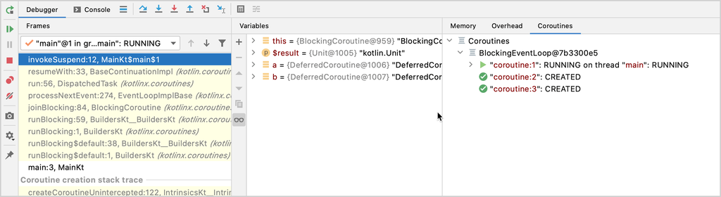

3. Resume the debugger session by clicking **Resume program** in the **Debug** tool window:

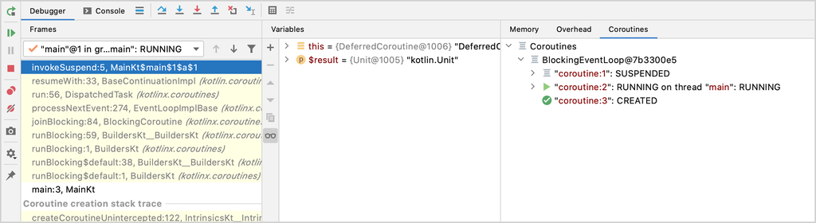

   Now the **Coroutines** tab shows the following:
   - The first coroutine has the **SUSPENDED** status – it is waiting for the values so it can multiply them.
   - The second coroutine is calculating the `a` value – it has the **RUNNING** status.
   - The third coroutine has the **CREATED** status and isn’t calculating the value of `b`.
4. Resume the debugger session by clicking **Resume program** in the **Debug** tool window:

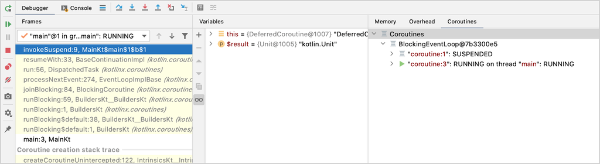

   Now the **Coroutines** tab shows the following:
   - The first coroutine has the **SUSPENDED** status – it is waiting for the values so it can multiply them.
   - The second coroutine has computed its value and disappeared.
   - The third coroutine is calculating the value of `b` – it has the **RUNNING** status.

Using IntelliJ IDEA debugger, you can dig deeper into each coroutine to debug your code.

© 2010–2020 JetBrains s.r.o. and Kotlin Programming Language contributors  
Licensed under the Apache License, Version 2.0.  
https://kotlinlang.org/docs/tutorials/coroutines/debug-coroutines-with-idea.html